# Análisis Epidemiológico en R

2019-02-28

## Temario

1. **Introducción** (30min)
   - Objetivos
   - Material de clase: Archivos R y Rmarkdown.
2. **Estudios observacionales** (85min)
   - Caso-Control, Cohorte, Tiempo a evento
3. RECESO (20min)
4. **Modelos Lineales Generalizados** (55min)
   - Múltiples covariables
   - Distribuciones y funciones de enlace
   - Caso-Control, Cohorte
5. **Transversales** (50min)
   - Situación 1: prevalencia < 10%
   - Situación 2: no convergencia
6. CIERRE

## Objetivo

- Calcular e interpretar medidas de asociación empleadas en Estudios Epidemiológicos.

### Objetivos Específicos

- Conocer las caracaterísticas de R y Rstudio.
- Importar, describir y ejecutar análisis a partir de bases de datos.
- Tomar decisiones epidemiológicas y estadísticas en base a la pregunta y tipo de estudio.

## Material de clase (1/3)

- **R**: Software Libre para el manejo, visualización y análisis de datos.
- **RStudio**: ambiente de desarrollo integrado (IDE).
- **Paquete**: Conjunto de funciones.
- **Función**: Código capaz de resolver un problema específico con datos.

[figure not shown]

## Material de clase (2/3)

- **R**: Software Libre para el manejo, visualización y análisis de datos.
- **RStudio**: ambiente de desarrollo integrado (IDE).
- **Paquete**: Conjunto de funciones.
- **Función**: Código capaz de resolver un problema específico con datos.

[figure not shown]

## Material de clase (3/3)

- Archivo **.R**: Documento en *texto plano* con **funciones** para resolver un problema de análisis amplio.
- Archivo **.Rmd**: Documento en *texto plano* que integra **texto, funciones y resultados**.

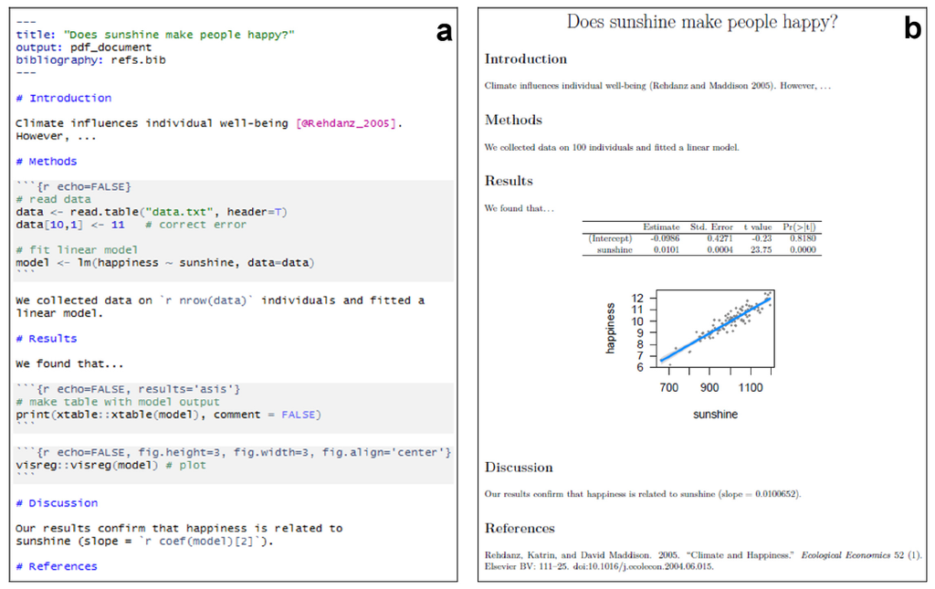

## Estudios Observacionales

- Asociar:
  - condición (**expuesto** o no-expuesto) y
  - resultado (**caso** o control)
- El tipo de análisis depende del tipo de estudio:
  - *“Reclutamos \(x_1\) sujetos **caso** y \(x_2\) sujetos **control**”* -> Tipo **Caso-Control**
  - *“Reclutamos \(x_1\) sujetos **expuestos** y \(x_2\) sujetos **no expuestos**”* -> Tipo **Cohorte**

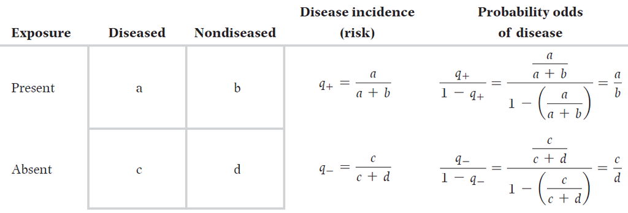

## 1.1 Caso-Control

- El investigador elige el total de **casos y controles**
- Si cambiamos el tamaño del grupo (**casos x 100**), **sí cambia** el Riesgo Relativo (RR)
- En estudios caso-control usamos el **Odds Ratio (OR)**

```
## # A tibble: 2 x 7
##   ccr2    Yes    No  risk  odds     rr     or
##   <fct> <dbl> <int> <dbl> <dbl>  <dbl>  <dbl>
## 1 Yes    3100    63 0.980  49.2  0.995  0.733
## 2 No    14900   222 0.985  67.1 NA     NA
```

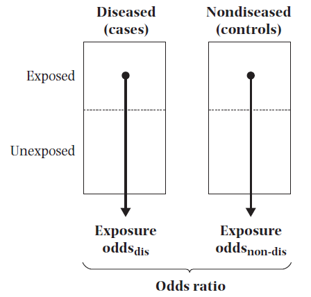

## 1.2 Pregunta de investigación

**En personas VIH+ ¿el polimorfismo CCR5(Delta-32) está *asociado* con el desarrollo del SIDA?**

- base: `aidsdb.dta`
- exposición: `ccr5`
- desenlace: `aids`

```r
aidsdb_or <- read_dta("data/aidsdb.dta") %>% as_factor() %>%
  group_by(aids) %>% sample_n(150) %>% ungroup()
```

- Simularemos un escenario Caso-Control: muestreo al azar de **150 casos y 150 controles**

```
## Observations: 300
## Variables: 10
## $ studyid       <dbl> 305636, 279772, 322022, 549808, 490172, 328297, 298549, 243450, 104463, 135567, 385200, 20161...
## $ ttoaidsorexit <dbl> 1016, 2209, 607, 936, 2391, 3336, 2066, 1464, 2315, 1428, 2031, 2233, 3345, 1121, 2833, 1770,...
## $ aids          <fct> Yes, Yes, Yes, Yes, Yes, Yes, Yes, Yes, Yes, Yes, Yes, Yes, Yes, Yes, Yes, Yes, Yes, Yes, Yes...
## $ age           <dbl> 30, 28, 29, 35, 22, 33, 30, 39, 31, 35, 54, 30, 31, 32, 39, 44, 35, 25, 25, 46, 43, 43, 49, 2...
## $ race          <fct> race2, race1, race1, race1, race1, race1, race1, race1, race1, race3, race1, race1, race1, ra...
## $ loghivrna     <dbl> 12.604708, 9.630694, 12.018091, 12.440480, 9.655026, 8.002359, 10.209169, 5.703783, 10.649203...
## $ cd4           <dbl> 791, 496, 253, 597, 932, 1016, 876, 900, 763, 530, 1096, 696, NA, 804, 662, 882, 853, 360, 63...
## $ ccr2          <fct> No, Yes, No, No, Yes, Yes, No, No, No, No, Yes, No, No, No, No, No, No, No, No, No, No, No, N...
## $ ccr5          <fct> No, No, No, No, Yes, No, No, No, No, No, No, No, No, No, No, No, No, No, No, Yes, Yes, No, No...
## $ sdf1          <fct> No, No, No, No, No, No, No, No, No, No, No, No, No, No, No, No, No, No, No, No, No, No, No, N...
```

## 1.3 Estimar e interpretar OR (1)

```r
epi.2by2(with(aidsdb_or,table(ccr5,aids)),
         method = "case.control")
```

```
##              Outcome +    Outcome -      Total        Prevalence *        Odds
## Exposed +           33           27         60                55.0       1.222
## Exposed -          117          123        240                48.8       0.951
## Total              150          150        300                50.0       1.000
##
## Point estimates and 95 % CIs:
## -------------------------------------------------------------------
## Odds ratio (W)                               1.28 (0.73, 2.27)
## Attrib prevalence *                          6.25 (-7.84, 20.34)
## Attrib prevalence in population *            1.25 (-7.24, 9.74)
## Attrib fraction (est) in exposed  (%)        22.11 (-42.73, 57.78)
## Attrib fraction (est) in population (%)      4.88 (-6.54, 15.07)
## -------------------------------------------------------------------
##  X2 test statistic: 0.75 p-value: 0.386
##  Wald confidence limits
##  * Outcomes per 100 population units
```

## 1.3 Estimar e interpretar OR (2)

\[OR = \frac{ {Odds}_{(Y: AIDS | CCR5:Yes)} }{ {Odds}_{(Y: AIDS | CCR5:No)} }\]

- En la población, el **odds** de tener sida dado que **sí poseen CCR5** es
- **1.28** veces,
- el **odds** de tener sida dado que **no poseen CCR5**,
- con un intervalo de confianza al 95% de 0.73 a 2.27.
- Este resultado no es estadísticamente significativo con un valor **p = 0.386**

## 1.3 Estimar e interpretar OR (3)

- segundo método

```r
aidsdb_or_no <- aidsdb_or %>% mutate_if(is.factor,fct_relevel, ... = "No")
compareGroups(aids ~ ccr5 + race,data = aidsdb_or_no,byrow=T) %>%
  createTable(show.ratio = T)
```

```
##
## --------Summary descriptives table by 'aids'---------
##
## ____________________________________________________________________
##               No          Yes            OR        p.ratio p.overall
##              N=150       N=150
## ¯¯¯¯¯¯¯¯¯¯¯¯¯¯¯¯¯¯¯¯¯¯¯¯¯¯¯¯¯¯¯¯¯¯¯¯¯¯¯¯¯¯¯¯¯¯¯¯¯¯¯¯¯¯¯¯¯¯¯¯¯¯¯¯¯¯¯¯
## ccr5:                                                        0.470
##     No    123 (51.2%) 117 (48.8%)       Ref.        Ref.
##     Yes   27 (45.0%)  33 (55.0%)  1.28 [0.73;2.28]  0.392
## race:                                                        0.156
##     race1 123 (47.9%) 134 (52.1%)       Ref.        Ref.
##     race2 18 (66.7%)   9 (33.3%)  0.46 [0.19;1.05]  0.067
##     race3  9 (56.2%)   7 (43.8%)  0.72 [0.25;2.02]  0.528
## ¯¯¯¯¯¯¯¯¯¯¯¯¯¯¯¯¯¯¯¯¯¯¯¯¯¯¯¯¯¯¯¯¯¯¯¯¯¯¯¯¯¯¯¯¯¯¯¯¯¯¯¯¯¯¯¯¯¯¯¯¯¯¯¯¯¯¯¯
```

## 1.4 **Tu turno 1**

**En personas VIH+ ¿el polimorfismo SDF1(CXCR12) O CCR2 está *asociado* con el desarrollo del SIDA?**

```r
compareGroups(aids ~ ccr5 + _____ + ______,data = aidsdb_or,byrow=T) %>%
  createTable(show.ratio = T)
```

```r
epi.2by2(with(aidsdb_or,table(_____,aids)),
         method = "case.control")

epi.2by2(with(aidsdb_or,table(_____,aids)),
         method = "case.control")
```

- **Interpretacíón:**

## 2.1 Cohorte

- El investigador puede elegir el total de **expuestos y no expuestos**

```
## # A tibble: 2 x 5
##   ccr5    Yes    No  risk    rr
##   <fct> <int> <int> <dbl> <dbl>
## 1 Yes      35    49 0.417  1.09
## 2 No      145   236 0.381 NA
```

- Si cambiamos el tamaño del grupo (**no-expuestos x 100**), **no cambia** el Riesgo Relativo (RR)

```
## # A tibble: 2 x 5
##   ccr5    Yes    No  risk    rr
##   <fct> <dbl> <dbl> <dbl> <dbl>
## 1 Yes      35    49 0.417  1.09
## 2 No    14500 23600 0.381 NA
```

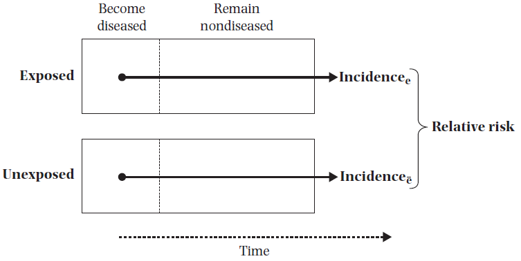

## 2.2 Pregunta de investigación (2)

**En personas VIH+ ¿el polimorfismo CCR5(Delta-32) *protege* contra el desarrollo del SIDA?**

- base: `aidsdb.dta`
- exposición: `ccr5`
- desenlace: `aids`

```r
aidsdb <- read_dta("data/aidsdb.dta") %>% as_factor()
```

```
## Observations: 465
## Variables: 10
## $ studyid       <dbl> 101750, 101780, 103328, 104463, 104525, 107858, 108299, 108831, 109749, 110129, 112245, 11421...
## $ ttoaidsorexit <dbl> 1019, 2809, 1717, 2315, 3764, 2643, 1185, 3636, 2213, 1692, 2950, 3782, 2918, 1061, 1461, 264...
## $ aids          <fct> Yes, No, Yes, Yes, No, Yes, Yes, Yes, Yes, No, No, No, Yes, No, Yes, No, Yes, No, No, No, Yes...
## $ age           <dbl> 22, 25, 32, 31, 39, 39, 32, 36, 43, 39, 28, 30, 28, 28, 38, 36, 37, 32, 44, 38, 33, 33, 32, 3...
## $ race          <fct> race1, race2, race1, race1, race1, race1, race1, race1, race1, race1, race1, race1, race1, ra...
## $ loghivrna     <dbl> 11.786481, 12.916421, 13.169676, 10.649203, 10.834726, 6.790097, 9.098403, NA, 12.690433, NA,...
## $ cd4           <dbl> 434, 391, 819, 763, 520, NA, 711, 2271, 402, 684, 530, 740, 473, 746, 531, 804, 450, 385, 481...
## $ ccr2          <fct> No, Yes, No, No, No, No, No, No, No, Yes, No, No, No, No, No, No, No, No, No, No, No, No, No,...
## $ ccr5          <fct> Yes, Yes, No, No, Yes, No, No, No, No, No, No, Yes, No, No, Yes, No, No, No, Yes, Yes, No, No...
## $ sdf1          <fct> No, No, No, No, Yes, No, No, No, No, No, No, No, No, No, No, No, No, No, No, No, No, No, No, ...
```

## 2.3 Estimar e interpretar RR (1)

```r
epi.2by2(with(aidsdb,table(ccr5,aids)),
         method = "cohort.count")
```

```
##              Outcome +    Outcome -      Total        Inc risk *        Odds
## Exposed +           35           49         84              41.7       0.714
## Exposed -          145          236        381              38.1       0.614
## Total              180          285        465              38.7       0.632
##
## Point estimates and 95 % CIs:
## -------------------------------------------------------------------
## Inc risk ratio                               1.09 (0.82, 1.45)
## Odds ratio                                   1.16 (0.72, 1.88)
## Attrib risk *                                3.61 (-8.01, 15.22)
## Attrib risk in population *                  0.65 (-5.93, 7.24)
## Attrib fraction in exposed (%)               8.66 (-21.29, 31.22)
## Attrib fraction in population (%)            1.68 (-3.90, 6.97)
## -------------------------------------------------------------------
##  X2 test statistic: 0.378 p-value: 0.539
##  Wald confidence limits
##  * Outcomes per 100 population units
```

## 2.3 Estimar e interpretar RR (2)

\[RR = \frac{ {Risk}_{(Y: AIDS | CCR5:Yes)} }{ {Risk}_{(Y: AIDS | CCR5:No)} }\]

## 2.3 Estimar e interpretar RR (2)

- segundo método

```r
aidsdb_no <- aidsdb %>% mutate_if(is.factor,fct_relevel, ... = "No")
cs(aidsdb_no$aids,aidsdb_no$ccr5)
```

```
##
##           Exposure
## Outcome    Non-exposed Exposed Total
##   Negative 236         49      285
##   Positive 145         35      180
##   Total    381         84      465
##
##            Rne         Re      Rt
##   Risk     0.38        0.42    0.39
##
##                                          Estimate Lower95ci Upper95ci
##  Risk difference (attributable risk)     0.04     -0.08     0.14
##  Risk ratio                              1.09     0.77      1.54
##  Attr. frac. exp. -- (Re-Rne)/Re         0.09
##  Attr. frac. pop. -- (Rt-Rne)/Rt*100 %   1.68
##  Number needed to harm (NNH)             27.71    -12.31    6.91
##    or 1/(risk difference)
```

## 2.4 **Tu turno 2**

**En personas VIH+ ¿el polimorfismo SDF1(CXCR12) o CCR2 *protege* contra el desarrollo del SIDA?**

```r
epi.2by2(with(aidsdb,table(_____,aids)),
         method = "cohort.count")

epi.2by2(with(aidsdb,table(_____,aids)),
         method = "cohort.count")
```

- **Interpretacíón:**

## 3.1 Tiempo a evento (1)

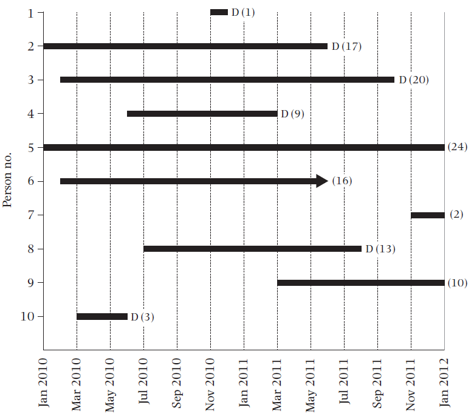

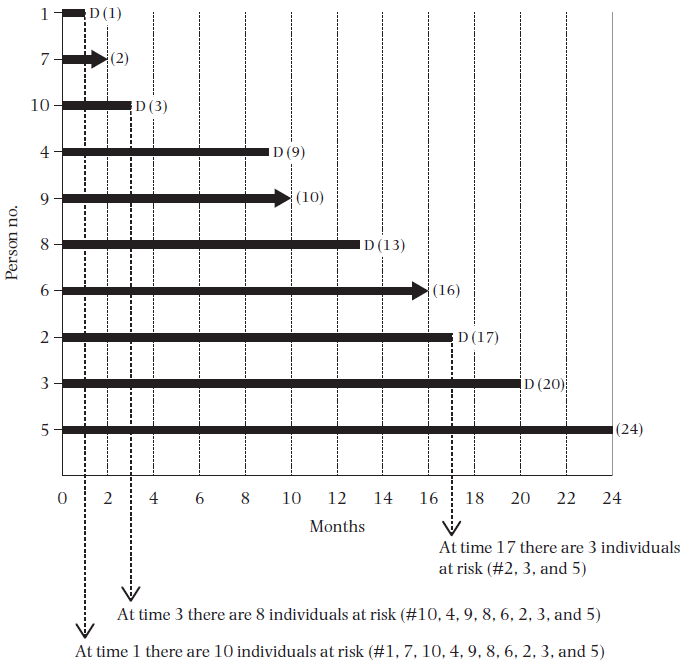

## 3.1 Tiempo a evento (2)

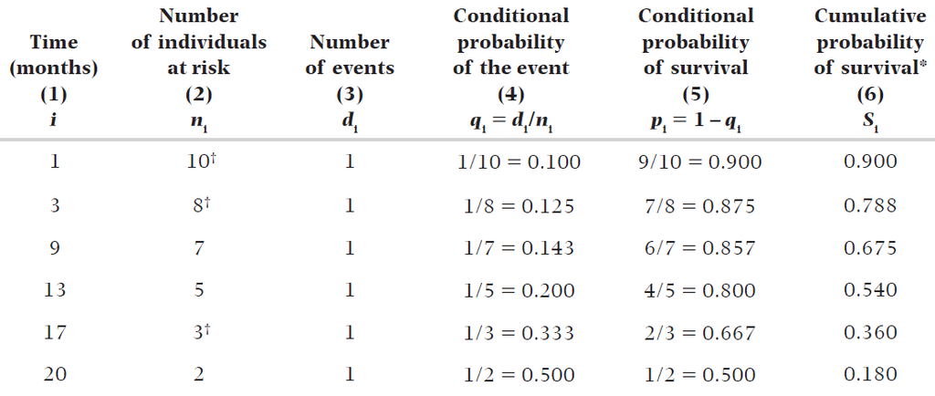

## 3.1 Tiempo a evento (3)

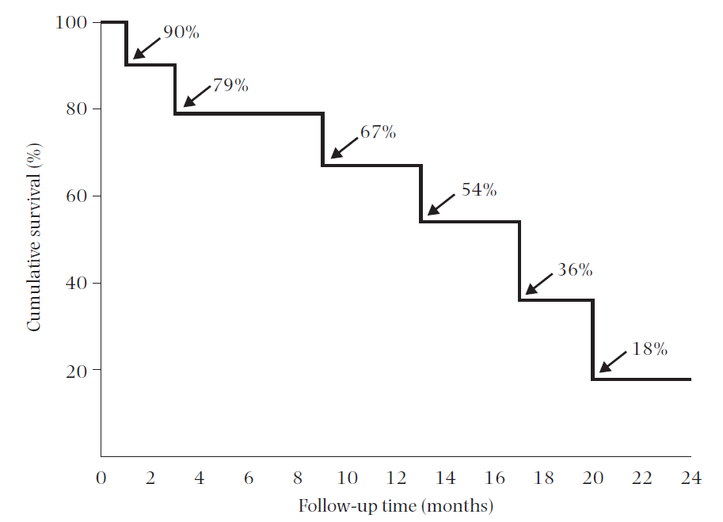

## 3.2 Pregunta de investigación (3)

**En personas VIH+ ¿el polimorfismo CCR5(Delta-32) contribuye con un mayor *tiempo* al inicio del SIDA?**

- base: `aidsdb.dta`
- exposición: `ccr5`
- tiempo a evento: `ttoaidsorexit`
- desenlace: `aids`

```r
coxdb <- read_dta("data/aidsdb.dta") %>% as_factor() %>%
  mutate(aids=as.integer(aids)-1)
```

```
## Observations: 465
## Variables: 10
## $ studyid       <dbl> 101750, 101780, 103328, 104463, 104525, 107858, 108299, 108831, 109749, 110129, 112245, 11421...
## $ ttoaidsorexit <dbl> 1019, 2809, 1717, 2315, 3764, 2643, 1185, 3636, 2213, 1692, 2950, 3782, 2918, 1061, 1461, 264...
## $ aids          <dbl> 0, 1, 0, 0, 1, 0, 0, 0, 0, 1, 1, 1, 0, 1, 0, 1, 0, 1, 1, 1, 0, 0, 1, 1, 1, 0, 0, 0, 0, 0, 1, ...
## $ age           <dbl> 22, 25, 32, 31, 39, 39, 32, 36, 43, 39, 28, 30, 28, 28, 38, 36, 37, 32, 44, 38, 33, 33, 32, 3...
## $ race          <fct> race1, race2, race1, race1, race1, race1, race1, race1, race1, race1, race1, race1, race1, ra...
## $ loghivrna     <dbl> 11.786481, 12.916421, 13.169676, 10.649203, 10.834726, 6.790097, 9.098403, NA, 12.690433, NA,...
## $ cd4           <dbl> 434, 391, 819, 763, 520, NA, 711, 2271, 402, 684, 530, 740, 473, 746, 531, 804, 450, 385, 481...
## $ ccr2          <fct> No, Yes, No, No, No, No, No, No, No, Yes, No, No, No, No, No, No, No, No, No, No, No, No, No,...
## $ ccr5          <fct> Yes, Yes, No, No, Yes, No, No, No, No, No, No, Yes, No, No, Yes, No, No, No, Yes, Yes, No, No...
## $ sdf1          <fct> No, No, No, No, Yes, No, No, No, No, No, No, No, No, No, No, No, No, No, No, No, No, No, No, ...
```

## 3.3 Generar tabla Kaplan Meier

```r
fit <- survfit(Surv(ttoaidsorexit, aids) ~ ccr5, data =  coxdb)
```

```r
#summary(fit)
fit %>% broom::tidy() #revisa el estrato!
```

```
## # A tibble: 451 x 9
##     time n.risk n.event n.censor estimate std.error conf.high conf.low strata
##    <dbl>  <dbl>   <dbl>    <dbl>    <dbl>     <dbl>     <dbl>    <dbl> <chr>
##  1    33     84       1        0    0.988    0.0120     1        0.965 ccr5=Yes
##  2   482     83       0        1    0.988    0.0120     1        0.965 ccr5=Yes
##  3   731     82       0        1    0.988    0.0120     1        0.965 ccr5=Yes
##  4   796     81       1        0    0.976    0.0173     1        0.943 ccr5=Yes
##  5   815     80       0        1    0.976    0.0173     1        0.943 ccr5=Yes
##  6   879     79       0        1    0.976    0.0173     1        0.943 ccr5=Yes
##  7   885     78       0        1    0.976    0.0173     1        0.943 ccr5=Yes
##  8   954     77       1        0    0.963    0.0216     1        0.923 ccr5=Yes
##  9  1006     76       1        0    0.951    0.0254     0.999    0.904 ccr5=Yes
## 10  1019     75       0        1    0.951    0.0254     0.999    0.904 ccr5=Yes
## # ... with 441 more rows
```

```r
#(1-(1/84)) * (1-(1/81))
```

## 3.3 Generar gráfico e interpretar (1)

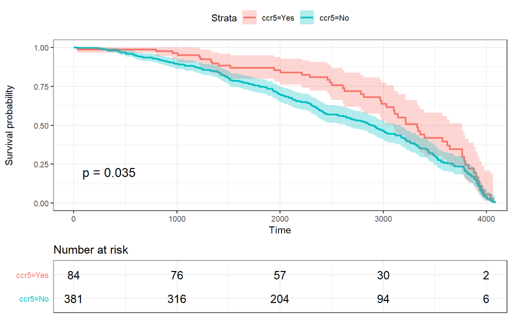

## 3.3 Generar gráfico e interpretar (2)

```r
survdiff(Surv(ttoaidsorexit, aids) ~ ccr5, data =  coxdb)
```

```
## Call:
## survdiff(formula = Surv(ttoaidsorexit, aids) ~ ccr5, data = coxdb)
##
##            N Observed Expected (O-E)^2/E (O-E)^2/V
## ccr5=Yes  84       49     63.7     3.400      4.44
## ccr5=No  381      236    221.3     0.979      4.44
##
##  Chisq= 4.4  on 1 degrees of freedom, p= 0.04
```

- **Interpretación**
- En la población,
- (la sobrevida) el tiempo a desarrollar AIDS en sujetos CCR5+
- es **mayor** a
- (la sobrevida) el tiempo a desarrollar AIDS en sujetos CCR5-.
- Este resultado es estadísticamente significativo con un **p < 0.05**

## 3.4 **Tu turno 3**

**En personas VIH+ ¿el polimorfismo SDF1(CXCR12) o CCR2 contribuyen con un mayor *tiempo* al inicio del SIDA?**

```r
fit <- survfit(Surv(ttoaidsorexit, aids) ~ ____, data =  coxdb)

fit %>% broom::tidy() #revisa el estrato!

survdiff(Surv(ttoaidsorexit, aids) ~ _____, data =  coxdb)

ggsurvplot(fit, data = coxdb, risk.table = TRUE,
           conf.int = T,ggtheme = theme_bw(),#ggtheme = theme_minimal(),
           pval = T,censor=FALSE,tables.theme = theme_cleantable())
```

- **Interpretación**

## RECESO

## Múltiples covariables

### características

- **dos o más** variables independientes (múltiple)
- **una** variable dependiente

### objetivo

- **Epidemiológico**: controlar **confusión** en el análisis.
  - estandarización (directa/indirecta),
  - estratificación,
  - puntajes de propensión,
  - regresión *multivariable*
- **Estadístico**: emplear **múltiples predictores**
  - lineales, no-lineales, segmentadas

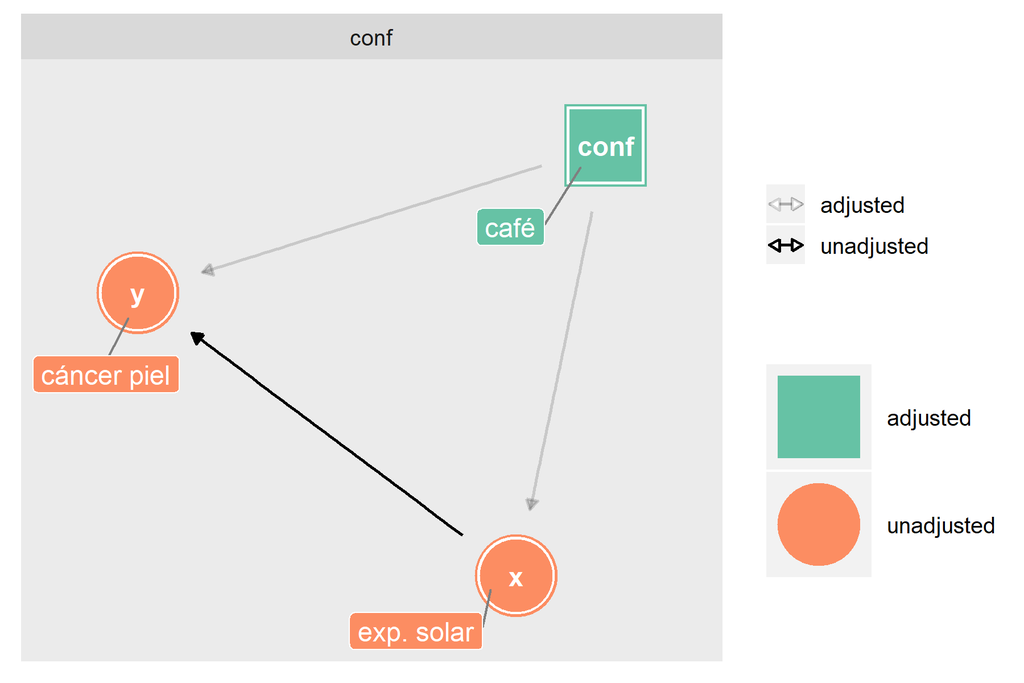

## GLM: verosimilitud

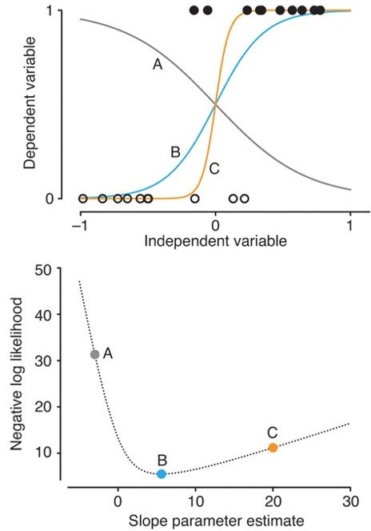

- GLM = Modelos Lineales Generalizados
- La estimación de parámetros se da por un proceso de optimización llamado **máxima verosimilitud** (o *likelihood*)
- GLM ajusta modelos lineales de \(g(y)\) con covaribles \(x\)

\[ g(Y) = \beta_0 + \sum_{n=1}^{n} \beta_n X_n \enspace , \enspace y \sim F \]

Donde:

- \(F\) es la familia de distribución
- \(g(\space)\) es la función de enlace

## 4.1 Caso-Control

- **OR:** **familia:** binomial, **link:** logit

\[ logit(p) = log(odds) = log\left(\frac{p}{1-p}\right) \\ logit(p) = \beta_0 + \beta_1 X_1 + . . . + \beta_n X_n + \epsilon \enspace ; \enspace y \sim Binomial \]

- El valor exponenciado de los coeficientes se pueden interpretar como **Odds Ratio (OR)**

\[ Y = \beta_0 + \beta_1 X_1 \\ \begin{cases} Y_{x=1} = log(odds_{x=1}) = \beta_0 + \beta_1(1) \\ Y_{x=0} = log(odds_{x=0}) = \beta_0 + \beta_1(0) \end{cases} \\ Y_{x=1} - Y_{x=0} = \beta_1 \\ log(odds_{x=1}) - log(odds_{x=0}) = \beta_1 \\ log \left(\frac{odds_{x=1}}{odds_{x=0}}\right) = \beta_1 \\ OR = exp(\beta_1) \]

## 4.2 Pregunta de investigación

**En personas VIH+, ajustando por raza ¿el polimorfismo CCR5 está *asociado* con el desarrollo del SIDA?**

- base: `aidsdb.dta`
- covariable: `race`
- exposición: `ccr5`
- desenlace: `aids`

```
## Observations: 300
## Variables: 10
## $ studyid       <dbl> 305636, 279772, 322022, 549808, 490172, 328297, 298549, 243450, 104463, 135567, 385200, 20161...
## $ ttoaidsorexit <dbl> 1016, 2209, 607, 936, 2391, 3336, 2066, 1464, 2315, 1428, 2031, 2233, 3345, 1121, 2833, 1770,...
## $ aids          <fct> Yes, Yes, Yes, Yes, Yes, Yes, Yes, Yes, Yes, Yes, Yes, Yes, Yes, Yes, Yes, Yes, Yes, Yes, Yes...
## $ age           <dbl> 30, 28, 29, 35, 22, 33, 30, 39, 31, 35, 54, 30, 31, 32, 39, 44, 35, 25, 25, 46, 43, 43, 49, 2...
## $ race          <fct> race2, race1, race1, race1, race1, race1, race1, race1, race1, race3, race1, race1, race1, ra...
## $ loghivrna     <dbl> 12.604708, 9.630694, 12.018091, 12.440480, 9.655026, 8.002359, 10.209169, 5.703783, 10.649203...
## $ cd4           <dbl> 791, 496, 253, 597, 932, 1016, 876, 900, 763, 530, 1096, 696, NA, 804, 662, 882, 853, 360, 63...
## $ ccr2          <fct> No, Yes, No, No, Yes, Yes, No, No, No, No, Yes, No, No, No, No, No, No, No, No, No, No, No, N...
## $ ccr5          <fct> No, No, No, No, Yes, No, No, No, No, No, No, No, No, No, No, No, No, No, No, Yes, Yes, No, No...
## $ sdf1          <fct> No, No, No, No, No, No, No, No, No, No, No, No, No, No, No, No, No, No, No, No, No, No, No, N...
```

## 4.3 Interpretar variables categóricas

```r
wm1 <- glm(aids ~ ccr5 + race, data = aidsdb_or_no, family = binomial(link = "logit"))
```

```
## # A tibble: 4 x 6
##   term         log.or    or conf.low conf.high p.value
##   <chr>         <dbl> <dbl>    <dbl>     <dbl>   <dbl>
## 1 (Intercept)  0.0445 1.05     0.794      1.38  0.751
## 2 ccr5Yes      0.186  1.20     0.679      2.15  0.525
## 3 racerace2   -0.752  0.471    0.195      1.07  0.0797
## 4 racerace3   -0.308  0.735    0.255      2.04  0.555
```

## 4.3 Interpretar variables contínuas

```r
wm1 <- glm(aids ~ ccr5 + age, data = aidsdb_or_no, family = binomial(link = "logit"))
```

```
## # A tibble: 3 x 6
##   term         log.or    or conf.low conf.high p.value
##   <chr>         <dbl> <dbl>    <dbl>     <dbl>   <dbl>
## 1 (Intercept)  0.725  2.07     0.723      5.99   0.178
## 2 ccr5Yes      0.245  1.28     0.724      2.27   0.399
## 3 age         -0.0222 0.978    0.949      1.01   0.138
```

## 4.4 **Tu turno 4**

**En adultos ¿la obesidad está *asociada* con la enfermedad cardiovascular?**

- usar base: cardio

```r
cardio <- read_dta("data/cardio.dta") %>% as_factor()
```

## 5.1 Cohorte

- **RR:** **familia:** binomial, **link:** log

\[ log(p) = \beta_0 + \beta_1 X_1 + . . . + \beta_n X_n + \epsilon \enspace ; \enspace y \sim Binomial \]

- El valor exponenciado de los coeficientes se pueden interpretar como **Risk Ratio (RR)**

\[ Y = \beta_0 + \beta_1 X_1 \\ \begin{cases} Y_{x=1} = log(p_{x=1}) = \beta_0 + \beta_1(1) \\ Y_{x=0} = log(p_{x=0}) = \beta_0 + \beta_1(0) \end{cases} \\ Y_{x=1} - Y_{x=0} = \beta_1 \\ log(p_{x=1}) - log(p_{x=0}) = \beta_1 \\ log \left(\frac{p_{x=1}}{p_{x=0}}\right) = \beta_1 \\ RR = exp(\beta_1) \]

## 5.2 Pregunta de investigación

**En personas VIH+, ajustando por raza, ¿el polimorfismo CCR5(Delta-32) *protege* contra el desarrollo del SIDA?**

- base: `aidsdb.dta`
- covariable: `race`
- exposición: `ccr5`
- desenlace: `aids`

```
## Observations: 465
## Variables: 10
## $ studyid       <dbl> 101750, 101780, 103328, 104463, 104525, 107858, 108299, 108831, 109749, 110129, 112245, 11421...
## $ ttoaidsorexit <dbl> 1019, 2809, 1717, 2315, 3764, 2643, 1185, 3636, 2213, 1692, 2950, 3782, 2918, 1061, 1461, 264...
## $ aids          <fct> Yes, No, Yes, Yes, No, Yes, Yes, Yes, Yes, No, No, No, Yes, No, Yes, No, Yes, No, No, No, Yes...
## $ age           <dbl> 22, 25, 32, 31, 39, 39, 32, 36, 43, 39, 28, 30, 28, 28, 38, 36, 37, 32, 44, 38, 33, 33, 32, 3...
## $ race          <fct> race1, race2, race1, race1, race1, race1, race1, race1, race1, race1, race1, race1, race1, ra...
## $ loghivrna     <dbl> 11.786481, 12.916421, 13.169676, 10.649203, 10.834726, 6.790097, 9.098403, NA, 12.690433, NA,...
## $ cd4           <dbl> 434, 391, 819, 763, 520, NA, 711, 2271, 402, 684, 530, 740, 473, 746, 531, 804, 450, 385, 481...
## $ ccr2          <fct> No, Yes, No, No, No, No, No, No, No, Yes, No, No, No, No, No, No, No, No, No, No, No, No, No,...
## $ ccr5          <fct> Yes, Yes, No, No, Yes, No, No, No, No, No, No, Yes, No, No, Yes, No, No, No, Yes, Yes, No, No...
## $ sdf1          <fct> No, No, No, No, Yes, No, No, No, No, No, No, No, No, No, No, No, No, No, No, No, No, No, No, ...
```

## 5.3 Interpretar coeficientes

```r
wm1 <- glm(aids ~ ccr5 + race, data = aidsdb, family = binomial(link = "log"))
```

```
## # A tibble: 4 x 6
##   term         log.rr    rr conf.low conf.high       p.value
##   <chr>         <dbl> <dbl>    <dbl>     <dbl>         <dbl>
## 1 (Intercept) -0.539  0.583    0.477     0.685 0.00000000286
## 2 ccr5No       0.0196 1.02     0.844     1.27  0.846
## 3 racerace2    0.285  1.33     1.08      1.56  0.00163
## 4 racerace3    0.0568 1.06     0.736     1.37  0.713
```

## 5.4 **Tu turno 5**

**En personas VIH+, ajustando por edad, ¿el polimorfismo CCR5(Delta-32) *protege* contra el desarrollo del SIDA?**

- base: `aidsdb.dta`
- covariable: `age`
- exposición: `ccr5`
- desenlace: `aids`
- **interpretar** edad.

## Transversales

**En adultos ¿la baja estatura está *asociada* con la depresión?**

```r
depres <- read_sav("data/depres.sav") %>% as_factor()
```

```r
wm1 <- glm(depress ~ short, data = depres, family = binomial(link = "log"))
```

```
## # A tibble: 2 x 6
##   term        log.pr    pr conf.low conf.high p.value
##   <chr>        <dbl> <dbl>    <dbl>     <dbl>   <dbl>
## 1 (Intercept) -2.23  0.107    0.103     0.112 0
## 2 shortYes     0.121 1.13     1.04      1.23  0.00526
```

- \(\beta_{estatura:baja}\)
- En la población, la **prevalencia** de tener depresión dado que se es de **estatura baja** es **1.13** veces,
- el **prevalencia** de tener depresión dado que se es de **estatura alta**,
- con un intervalo de confianza AL 95% de 1.04 a 1.23.
- Este resultado es estadísticamente significativo con un valor **p = 0.005**

## 6.1 Situación 1: prevalencia < 10%

**En adultos ¿la depresión está *asociada* con el evento cerebrovascular?**

- base: `depress.sav`
- exposición: `depress`
- desenlace: `cvd`
- prevalencia del desenlace: **8.96%**

```r
depres %>% count(cvd) %>% mutate(prev=n/sum(n))
```

```
## # A tibble: 2 x 3
##   cvd       n   prev
##   <fct> <int>  <dbl>
## 1 No    20033 0.910
## 2 Yes    1972 0.0896
```

## 6.1 Situación 1: prevalencia < 10%

**En adultos ¿la depresión está *asociada* con el evento cerebrovascular?**

```r
wm1 <- glm(cvd ~ depress, data = depres, family = binomial(link = "logit"))
```

```
## # A tibble: 2 x 6
##   term        log.or     or conf.low conf.high  p.value
##   <chr>        <dbl>  <dbl>    <dbl>     <dbl>    <dbl>
## 1 (Intercept) -2.42  0.0886   0.0841    0.0932 0.
## 2 depressYes   0.736 2.09     1.85      2.35   7.21e-33
```

```r
wm1 <- glm(cvd ~ depress, data = depres, family = binomial(link = "log"))
```

```
## # A tibble: 2 x 6
##   term        log.pr     pr conf.low conf.high  p.value
##   <chr>        <dbl>  <dbl>    <dbl>     <dbl>    <dbl>
## 1 (Intercept) -2.51  0.0813   0.0776    0.0852 0.
## 2 depressYes   0.651 1.92     1.73      2.12   7.40e-35
```

## 6.2 Situación 2: no convergencia

**En adultos ¿la actividad física está *asociada* con la hipercolesterolemia?**

```r
cronic <- read_rds("data/cronic.rds")
```

```r
cronic %>% count(tcho2,tcho2_n,tcho2_nn) %>% mutate(prev=n/sum(n))
```

```
## # A tibble: 2 x 5
##   tcho2 tcho2_n tcho2_nn     n  prev
##   <fct>   <dbl>    <dbl> <int> <dbl>
## 1 No          1        0   613 0.697
## 2 Yes         2        1   266 0.303
```

```r
#no convergencia
glm(tcho2 ~ age + sex + group + bmi_cat + diab + hba1c + ht + pa2 + smoke2 + alcohol2 + ndrug,
    data = cronic, family = binomial(link = "log"))
```

```
## Error: no valid set of coefficients has been found: please supply starting values
```

## 6.2 Situación 2: no convergencia

- Cambiar la familia de distribución **binomial** a **poisson**.
- Poisson es una caso especial de la distribución binomial.

```r
#alternativa: poisson
wm1 <- glm(tcho2_nn ~ age + sex + group + diab + hba1c + ht + pa2 + smoke2 + alcohol2 + ndrug,
    data = cronic, family = poisson(link = "log"))
```

```
## # A tibble: 13 x 7
##    term               log.pr    se    pr conf.low conf.high p.value
##    <chr>               <dbl> <dbl> <dbl>    <dbl>     <dbl>   <dbl>
##  1 (Intercept)         -4.21  0.65  0.01     0         0.05   0
##  2 age                  0.02  0.01  1.02     1         1.03   0.007
##  3 sexMale             -0.17  0.13  0.85     0.65      1.1    0.221
##  4 groupMigrant         1.58  0.27  4.85     2.95      8.62   0
##  5 groupUrban           1.48  0.3   4.38     2.5       8.15   0
##  6 diabYes             -0.28  0.66  0.75     0.19      2.5    0.666
##  7 hba1c                0.14  0.1   1.15     0.95      1.4    0.158
##  8 htYes                0.02  0.19  1.02     0.7       1.45   0.915
##  9 pa2low pa            0.04  0.14  1.05     0.79      1.37   0.755
## 10 smoke2Former >6mo    0.02  0.25  1.02     0.61      1.61   0.943
## 11 smoke2Current <6mo  -0.19  0.21  0.82     0.53      1.23   0.362
## 12 alcohol2Yes          0.04  0.24  1.04     0.63      1.62   0.88
## 13 ndrug                0.19  0.07  1.21     1.06      1.38   0.004
```

## 6.2 Situación 2: no convergencia

- Calcular **errores estandar robustos**
- Objetivo: controlar por violaciones en el supuesto de varianza igual a media en la regresión de Poisson.

```r
cov.m1 <- sandwich::vcovHC(wm1, type="HC0")
std.err <- sqrt(diag(cov.m1))
```

```
##                    Estimate Robust SE Pr(>|z|)    LL   UL
## (Intercept)            0.01      1.71     0.00 -3.33 3.36
## age                    1.02      1.00     0.00 -0.95 2.98
## sexMale                0.85      1.11     0.11 -1.33 3.02
## groupMigrant           4.85      1.29     0.00  2.31 7.39
## groupUrban             4.38      1.32     0.00  1.79 6.97
## diabYes                0.75      1.75     0.61 -2.67 4.18
## hba1c                  1.15      1.08     0.08 -0.97 3.28
## htYes                  1.02      1.17     0.90 -1.26 3.30
## pa2low pa              1.05      1.12     0.70 -1.15 3.24
## smoke2Former >6mo      1.02      1.23     0.93 -1.38 3.42
## smoke2Current <6mo     0.82      1.20     0.29 -1.53 3.18
## alcohol2Yes            1.04      1.22     0.86 -1.36 3.43
## ndrug                  1.21      1.05     0.00 -0.85 3.28
```

## 6.3 **Tu turno 6**

- **Situación 1:** Genera un modelo múltiple entre `depresión` y `ECV` tomando en cuenta `estatura` como confusor.
- **Situación 2:** Interpretar los coeficientes de la variable categórica `grupo`.

## Referencias

### Libro

- Szklo M. & FJ Nieto. Epidemiology. Beyond the basics. Third Edition. 2014.

### Presentaciones

- Curso de Bioestadística. Maestría en Ciencias de la Investigación Epidemiológica. UPCH 2018.
- Zavala JA. Regresión Lineal. 2018
- Akehurst H. Bioestadística con R. Julio 2016

### Enlaces web

- Statistics for Biologist: Points of Significance. Link: `https://www.nature.com/collections/qghhqm/pointsofsignificance`
- Association of gene polymorphism of SDF1(CXCR12) with susceptibility to HIV-1 infection and AIDS disease progression: A meta-analysis. PLoS One. 2018 Feb 8. `https://www.ncbi.nlm.nih.gov/pubmed/29420545`
- Protective effect of CCR5 Delta-32 allele against HIV-1 in Mexican women. Curr HIV Res. 2013 Sep `https://www.ncbi.nlm.nih.gov/pubmed/24382026`

## CIERRE: ¿Qué no hemos podido ver?

- Regresión de Cox (Hazard Ratio):
  - `http://www.sthda.com/english/wiki/cox-proportional-hazards-model`
- Selección de predictores en regresión múltiple por **LRT**:
  - `https://rstudio-pubs-static.s3.amazonaws.com/2899_a9129debf6bd47d2a0501de9c0dc583d.html`
- Análisis y visualización de **DAGs**: `https://ggdag.netlify.com/`
- Manipulación, limpieza y visualización de datos: `http://r4ds.had.co.nz/`

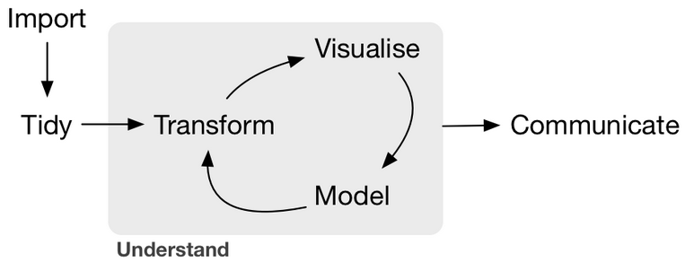

## CIERRE: Ciencia Reproducible

[figure not shown]

## CIERRE: Ciencia Reproducible

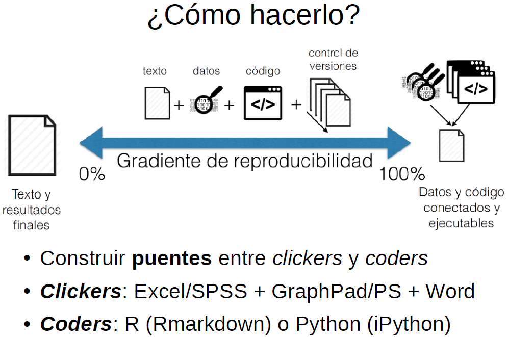